# Research Guide

Research Guide

## Categorical

categorical · geographic

state of birth

`birthState`

State or province where the player was born: a two-letter postal code for US states, a region name elsewhere (e.g. La Romana); blank if unknown

| ROWS | DISTINCT | MISSING/NA |
| --- | --- | --- |
| 678 | 115 (17.0%) | 17 (2.5%) |

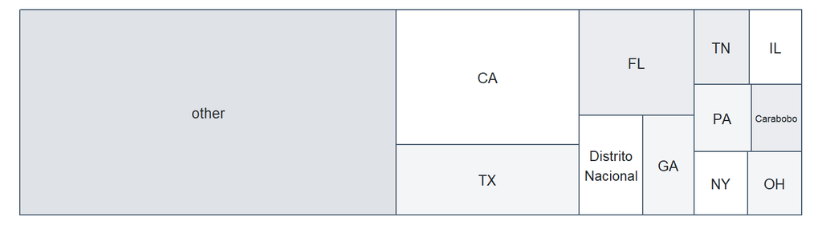

**PREVIEW**:

```
CA · TX · FL · Distrito Nacional · GA · TN · IL · PA · Carabobo · NY · OH · IN · MO
San Cristobal · NC · NJ · CT · MI · KY · San Pedro de Macoris · AL · MS · VA · LA · NV
```

**FACTOR LEVELS**:

| Frequency | (%) | Label |
| --- | --- | --- |
| 102 | (15.0%) | CA |
| 53 | (7.8%) | TX |
| 50 | (7.4%) | FL |
| 26 | (3.8%) | Distrito Nacional |
| 21 | (3.1%) | GA |
| 17 | (2.5%) | TN |
| 16 | (2.4%) | IL |
| 16 | (2.4%) | PA |

*+ 106 more levels*

categorical · geographic

city of birth

`birthCity`

City where the player was born; blank if unknown

| ROWS | DISTINCT |
| --- | --- |
| 678 | 452 (66.7%) |

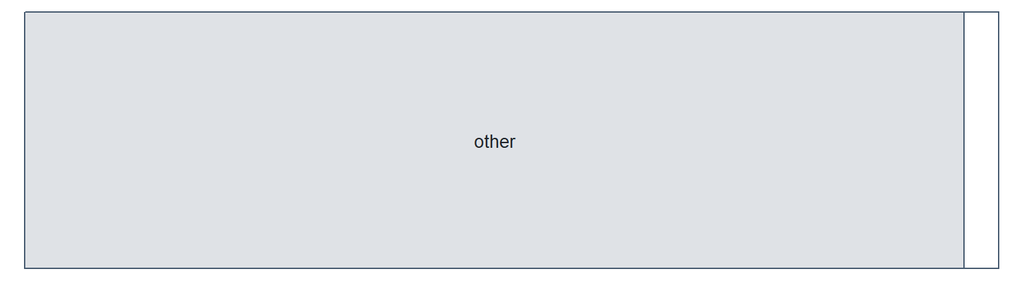

**PREVIEW**:

```
Santo Domingo · Valencia · Dallas · San Pedro de Macoris · Houston · Miami · La Habana
Las Vegas · San Cristobal · Atlanta · La Romana · Newport Beach · Anaheim · Birmingham
```

**FACTOR LEVELS**:

| Frequency | (%) | Label |
| --- | --- | --- |
| 24 | (3.5%) | Santo Domingo |
| 10 | (1.5%) | Valencia |
| 9 | (1.3%) | Dallas |
| 9 | (1.3%) | San Pedro de Macoris |
| 8 | (1.2%) | Houston |
| 7 | (1.0%) | Miami |
| 6 | (0.9%) | La Habana |
| 6 | (0.9%) | Las Vegas |

*+ 444 more levels*

categorical

height (inches)

`height`

Player's height in inches

| ROWS | DISTINCT |
| --- | --- |
| 678 | 15 (2.2%) |

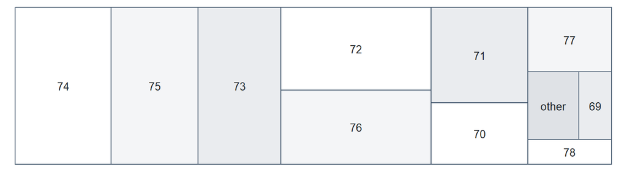

**PREVIEW**:

```
74 · 75 · 73 · 72 · 76 · 71 · 70 · 77 · 69 · 78 · 68 · 79 · 67 · 80 · 66
```

**FACTOR LEVELS**:

| Frequency | (%) | Label |
| --- | --- | --- |
| 109 | (16.1%) | 74 |
| 99 | (14.6%) | 75 |
| 94 | (13.9%) | 73 |
| 90 | (13.3%) | 72 |
| 81 | (11.9%) | 76 |
| 67 | (9.9%) | 71 |
| 43 | (6.3%) | 70 |
| 39 | (5.8%) | 77 |

*+ 7 more levels*

categorical · unordered

side of plate (R/L/B)

`bats`

Player's batting hand, coded R (right), L (left) or B (both)

| ROWS | DISTINCT |
| --- | --- |
| 678 | 3 (0.4%) |

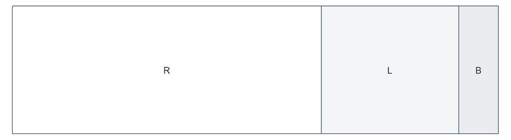

**PREVIEW**:

```
R · L · B
```

**FACTOR LEVELS**:

| Frequency | (%) | Label | Meaning |
| --- | --- | --- | --- |
| 431 | (63.6%) | R | R (right) |
| 192 | (28.3%) | L | L (left) |
| 55 | (8.1%) | B | B (both) |

categorical · unordered

throwing hand (L/R)

`throws`

Player's throwing hand, coded R (right) or L (left)

| ROWS | DISTINCT |
| --- | --- |
| 678 | 2 (0.3%) |

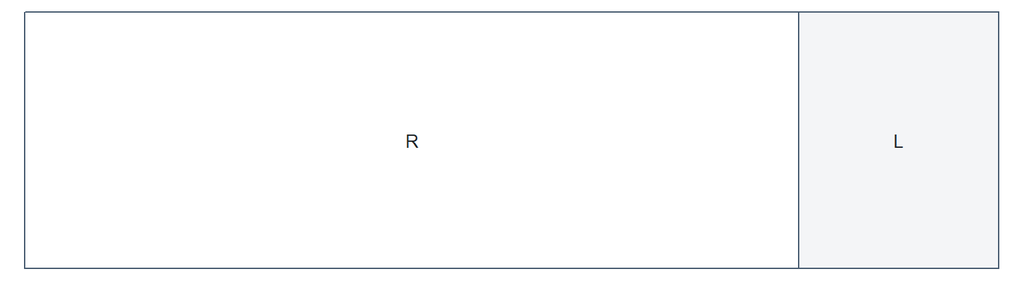

**PREVIEW**:

```
R · L
```

**FACTOR LEVELS**:

| Frequency | (%) | Label | Meaning |
| --- | --- | --- | --- |
| 539 | (79.5%) | R | R (right) |
| 139 | (20.5%) | L | L (left) |

## Numeric

number · measurement

weight (lbs)

`weight`

Player's weight in pounds

| ROWS | DISTINCT |
| --- | --- |
| 678 | 74 (10.9%) |

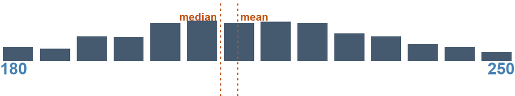

**PREVIEW**:

```
205 · 200 · 220 · 210 · 215 · 190 · 225 · 195 · 230 · 235 · 240 · 180 · 185 · 245 · 250 · 175
255 · 218 · 170 · 232 · 160 · 212 · 216 · 227 · 191 · 207 · 217 · 224 · 165 · 166 · 201 · 213
```

**STATS**:

| MIN | Q05 | Q25 | Q50 | MEAN | Q75 | Q95 | MAX |
| --- | --- | --- | --- | --- | --- | --- | --- |
| 160 | 180 | 200 | 210 | 212.32 | 225 | 246.15 | 315 |

number · measurement

games

`G`

Average game appearances per season

| ROWS | DISTINCT |
| --- | --- |
| 678 | 139 (20.5%) |

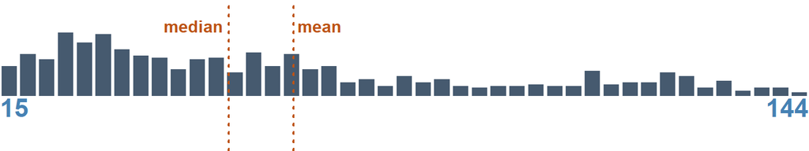

**PREVIEW**:

```
32 · 29 · 30 · 48 · 24 · 25 · 26 · 34 · 13 · 28 · 40 · 54 · 56 · 35 · 60 · 62 · 18 · 20 · 22
36 · 43 · 52 · 64 · 11 · 16 · 23 · 37 · 46 · 47 · 57 · 80 · 14 · 19 · 27 · 31 · 38 · 39 · 110
```

**STATS**:

| MIN | Q05 | Q25 | Q50 | MEAN | Q75 | Q95 | MAX |
| --- | --- | --- | --- | --- | --- | --- | --- |
| 11 | 15 | 30 | 51.5 | 61.78 | 86 | 141.15 | 159 |

number

at bats

`AB`

Average at bats per season; blank if the player has no recorded at bats

| ROWS | DISTINCT | MISSING/NA |
| --- | --- | --- |
| 678 | 284 (41.9%) | 136 (20.1%) |

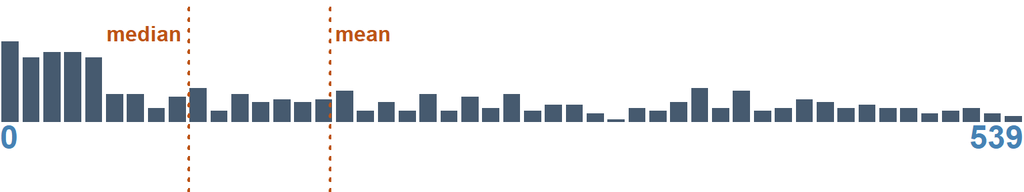

**PREVIEW**:

```
1 · 2 · 4 · 3 · 5 · 50 · 17 · 30 · 35 · 179 · 9 · 20 · 26 · 38 · 75 · 6 · 7 · 12 · 27 · 29 · 32
33 · 34 · 41 · 48 · 52 · 56 · 74 · 127 · 128 · 162 · 225 · 252 · 273 · 366 · 372 · 392 · 10 · 14
```

**STATS**:

| MIN | Q05 | Q25 | Q50 | MEAN | Q75 | Q95 | MAX |
| --- | --- | --- | --- | --- | --- | --- | --- |
| 1 | 1 | 9 | 99.5 | 173.8 | 308 | 532 | 634 |

number

hits

`H`

Average hits per season

| ROWS | DISTINCT | ZERO |
| --- | --- | --- |
| 678 | 145 (21.4%) | 264 (38.9%) |

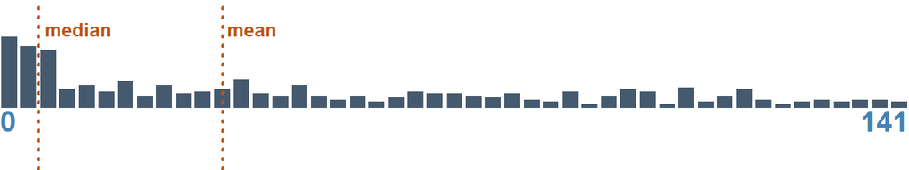

**PREVIEW**:

```
0 · 1 · 2 · 4 · 8 · 3 · 6 · 7 · 20 · 5 · 37 · 98 · 100 · 13 · 26 · 32 · 36 · 46 · 65 · 78 · 88
115 · 10 · 14 · 16 · 17 · 21 · 24 · 34 · 47 · 67 · 69 · 106 · 107 · 112 · 11 · 28 · 30 · 35 · 39
```

**STATS**:

| MIN | Q05 | Q25 | Q50 | MEAN | Q75 | Q95 | MAX |
| --- | --- | --- | --- | --- | --- | --- | --- |
| 0 | 0 | 0 | 6 | 34.55 | 62 | 138 | 197 |

number · measurement

batting average

`AVG`

Career batting average (hits / at bats over all seasons); blank if the player has no recorded at bats

| ROWS | DISTINCT | MISSING/NA | ZERO |
| --- | --- | --- | --- |
| 678 | 406 (59.9%) | 136 (20.1%) | 97 (14.3%) |

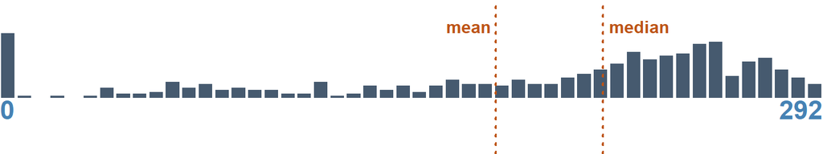

**PREVIEW**:

```
0 · 0.071 · 0.111 · 0.062 · 0.5 · 0.056 · 0.059 · 0.067 · 0.133 · 0.2 · 0.25 · 0.333 · 0.037
0.083 · 0.086 · 0.143 · 0.15 · 0.154 · 0.16 · 0.167 · 0.182 · 0.208 · 0.214 · 0.235
```

**STATS**:

| MIN | Q05 | Q25 | Q50 | MEAN | Q75 | Q95 | MAX |
| --- | --- | --- | --- | --- | --- | --- | --- |
| 0 | 0 | 0.08 | 0.21 | 0.18 | 0.25 | 0.29 | 1 |

number

slugging percentage

`SLUG`

Career slugging percentage (total bases / at bats over all seasons); blank if the player has no recorded at bats

| ROWS | DISTINCT | MISSING/NA | ZERO |
| --- | --- | --- | --- |
| 678 | 411 (60.6%) | 136 (20.1%) | 97 (14.3%) |

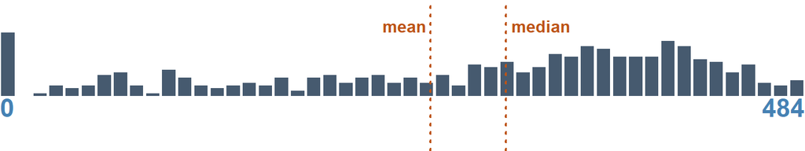

**PREVIEW**:

```
0 · 0.5 · 0.071 · 0.111 · 0.143 · 0.056 · 0.059 · 0.133 · 0.167 · 0.2 · 0.667 · 0.062 · 0.067
0.1 · 0.222 · 0.25 · 0.296 · 0.333 · 0.336 · 0.356 · 0.375 · 0.01 · 0.02 · 0.029
```

**STATS**:

| MIN | Q05 | Q25 | Q50 | MEAN | Q75 | Q95 | MAX |
| --- | --- | --- | --- | --- | --- | --- | --- |
| 0 | 0 | 0.1 | 0.3 | 0.26 | 0.39 | 0.48 | 1 |

number · usd

salary

Average annual salary over the player's career, in US dollars (written $851,950)

| ROWS | DISTINCT |
| --- | --- |
| 678 | 507 (74.8%) |

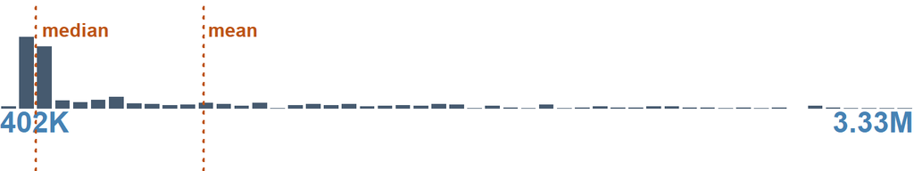

**PREVIEW**:

```
$510,000 · $414,000 · $509,500 · $507,500 · $512,500 · $480,000 · $508,500 · $520,000 · $500,000
$490,000 · $515,000 · $517,500 · $400,000 · $492,500 · $501,000 · $507,000 · $510,500 · $512,000
```

**STATS**:

| MIN | Q05 | Q25 | Q50 | MEAN | Q75 | Q95 | MAX |
| --- | --- | --- | --- | --- | --- | --- | --- |
| 4e+05 | 453,525 | 507,000 | 516,950 | 1,054,828 | 998,525 | 3,327,430 | 2.2e+07 |

## Text

text · person

first name

`nameFirst`

Player's first name

| ROWS | DISTINCT |
| --- | --- |
| 678 | 337 (49.7%) |

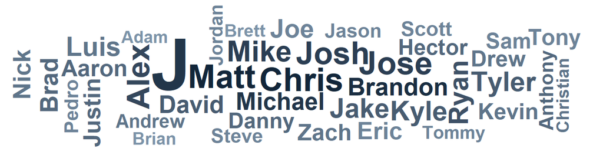

**PREVIEW**:

```
Chris · Matt · Brandon · Michael · Jose · Josh · Mike · Alex · Ryan · David · Jake · Kyle
Tyler · Aaron · Anthony · Brad · Danny · Hector · Justin · Andrew · Christian · Drew · Kevin
```

**MOST COMMON VALUES**:

| Value | Frequency | (%) |
| --- | --- | --- |
| Chris | 14 | (2.1%) |
| Matt | 14 | (2.1%) |
| Brandon | 13 | (1.9%) |
| Michael | 12 | (1.8%) |
| Jose | 11 | (1.6%) |
| Josh | 11 | (1.6%) |

text

last name

`nameLast`

Player's last name

| ROWS | DISTINCT |
| --- | --- |
| 678 | 607 (89.5%) |

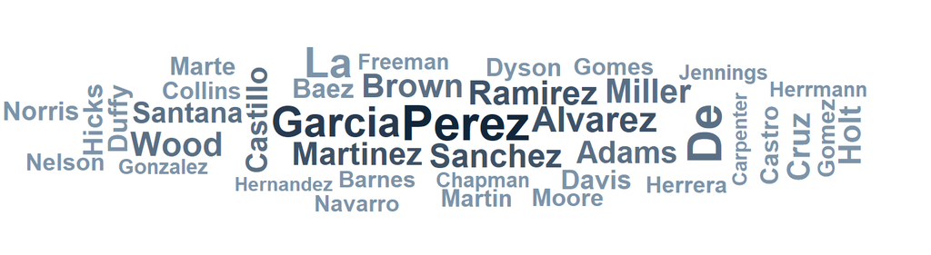

**PREVIEW**:

```
Perez · Garcia · Alvarez · Martinez · Ramirez · Sanchez · Adams · Brown · Castillo · Miller
Santana · Wood · Baez · Barnes · Carpenter · Castro · Chapman · Collins · Cruz · Davis · Duffy
```

**MOST COMMON VALUES**:

| Value | Frequency | (%) |
| --- | --- | --- |
| Perez | 6 | (0.9%) |
| Garcia | 5 | (0.7%) |
| Alvarez | 4 | (0.6%) |
| Martinez | 4 | (0.6%) |
| Ramirez | 4 | (0.6%) |
| Sanchez | 4 | (0.6%) |

## Temporal

temporal · calendar

date of birth

`birthDate`

Player's birth date, written Mon DD, YYYY (e.g. Dec 27, 1981)

| ROWS | DISTINCT |
| --- | --- |
| 678 | 616 (90.9%) |

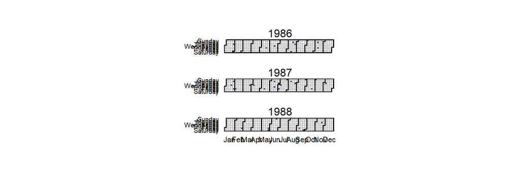

**PREVIEW**:

```
Apr 18, 1990 · Aug 26, 1986 · Dec 08, 1987 · Apr 08, 1987 · Apr 16, 1991 · Aug 08, 1989
Aug 10, 1987 · Aug 16, 1986 · Aug 18, 1986 · Aug 21, 1989 · Aug 25, 1987 · Aug 26, 1985
```

temporal · year

year of birth

`birthYear`

Year in which the player was born (YYYY)

| ROWS | DISTINCT |
| --- | --- |
| 678 | 18 (2.7%) |

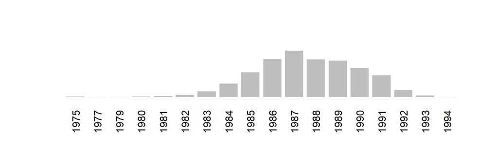

**PREVIEW**:

```
1987 · 1986 · 1988 · 1989 · 1990 · 1985 · 1991 · 1984 · 1992 · 1983 · 1982 · 1993 · 1981 · 1975
1980 · 1977 · 1979 · 1994
```

temporal · month_of_year

month of birth (Mon)

`birthMonth`

Month in which the player was born, as a three-letter abbreviation (Jan-Dec)

| ROWS | DISTINCT |
| --- | --- |
| 678 | 12 (1.8%) |

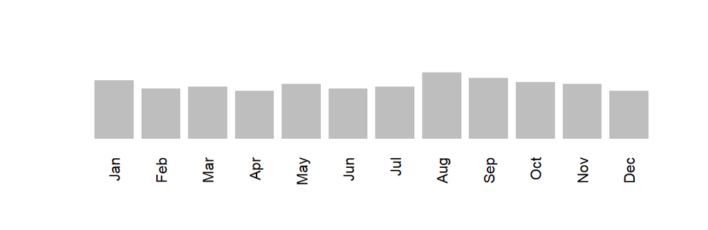

**PREVIEW**:

```
Aug · Sep · Jan · Oct · May · Nov · Jul · Mar · Feb · Jun · Apr · Dec
```

temporal · calendar

date of first appearance

`debut`

Date of the player's first major league appearance (YYYY-MM-DD)

| ROWS | DISTINCT |
| --- | --- |
| 678 | 428 (63.1%) |

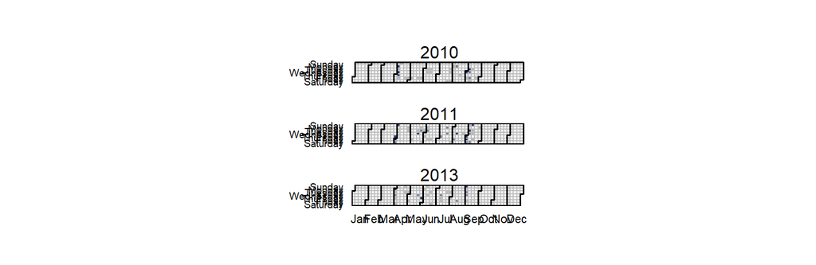

**PREVIEW**:

```
2011-09-06 · 2010-04-05 · 2010-09-01 · 2011-04-03 · 2012-04-07 · 2013-04-01 · 2014-09-01
2010-04-08 · 2011-03-31 · 2011-09-02 · 2010-04-07 · 2010-09-07 · 2011-04-01 · 2011-05-18
```

temporal · calendar

date of last appearance

`finalGame`

Date of the player's last major league appearance (YYYY-MM-DD)

| ROWS | DISTINCT |
| --- | --- |
| 678 | 399 (58.8%) |

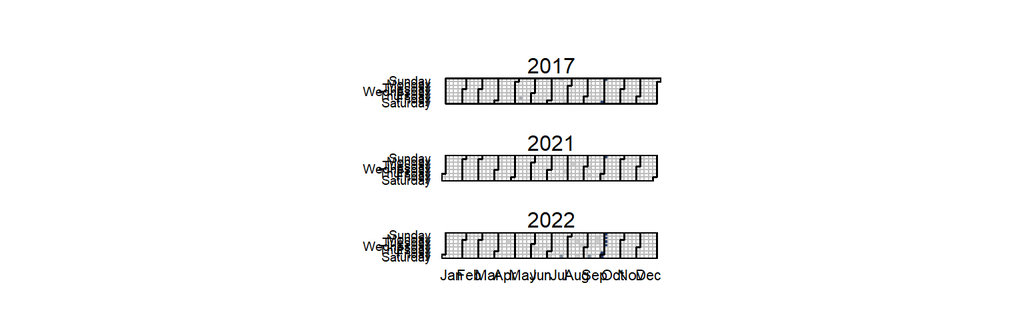

**PREVIEW**:

```
2022-10-05 · 2022-10-04 · 2016-10-02 · 2022-10-03 · 2017-10-01 · 2015-10-04 · 2019-09-29
2021-10-03 · 2022-10-02 · 2020-09-27 · 2022-10-01 · 2017-09-30 · 2022-09-30 · 2013-09-28
```